# What i learned so far on neural network

Author

Affiliation

Amir Fawwaz

HT Consulting (Asia) Sdn. Bhd.

Published

July 25, 2024

Keywords

Neural Network, Recurrent Neural Network, Generative AI

**Wisdom**

“Deep learning allows computational models that are composed of multiple processing layers to learn representations of data with multiple levels of abstraction.” - Yann LeCun.

# Preface

Deep learning has undoubtedly established itself as the outstanding machine learning technique of recent times. This dominant position has been claimed through a series of overwhelming successes in widely different application areas such as speech processing, autonomous driving, medical AI and security.

**Let us start with this **premise**

Deep learning refers to techniques where deep neural networks are trained with gradient-based methods.

In “supervised” deep learning we can equate the whole problem to $X \mapsto Y$. In another word, we have $X$ as input space, and $Y$ output space, and the learning is a process of mapping from $X$ to $Y$. The learner receives a set of labeled examples as training data and makes predictions for all unseen points.

# Data as Vectors

We assume that our data can be read by a computer, and represented adequately in a numerical format. Our data can come from tabular data, genomic sequences, text, image or audio. each input $x_{n}$ is a $D$-dimensional vector of real numbers, which are called *features*, *attributes*, or *covariates*.

For supervised learning problem where we have a *label* $y_{n}$ associated with each example $x_{n}$. The label $y_{n}$ has various other names, including target, response variable, and annotation. A dataset is written as a set of example label pairs $\{(x_1,y_1),...,(x_n,y_n)\}$

Since we have vector representations of data, we can manipulate data to find potentially better representations of it.From original feature vector, we can represent into lower-dimensional approximations (e.g. principal components). On the other hand, if we can represent it into high-dimensional representation will see an explicit *feature map* $\phi(\cdot)$ that allows us to represent inputs $x_{n}$ using a higher-dimensional representation $\phi(x_{n})$. The main motivation for higher-dimensional representations is that we can construct new features as non-linear combinations of the original features, which in turn may make the learning problem easier.

Before venture into the wild further, let’s revise our vector concept. You can think of a vector in simple terms as a list of numbers where the position of each item in this structure matters.

Consider the following column vector, where $\nu_{1}$ and $\nu_{2}$ each represent “some” feature.

$$\vec{\nu} = \begin{bmatrix}
\nu_{1} \\
\nu_{2} \\
\end{bmatrix} = \begin{bmatrix}
1.64 \\
64 \\
\end{bmatrix}$$

Additional operation is straight forward.

$$\vec{z} = \vec{\nu} + \vec{w}$$

$$\vec{z} = \begin{bmatrix}
2 \\
3 \\
\end{bmatrix} + \begin{bmatrix}
2 \\
1 \\
\end{bmatrix}$$

$$\vec{z} = \begin{bmatrix}
2 + 2 \\
3 + 1 \\
\end{bmatrix} = \begin{bmatrix}
4 \\
4 \\
\end{bmatrix}$$

Then for multiplying vectors we can use what we called the *dot product*. The other is called the *cross product*, which won’t be covered in this note. The main difference between the dot product and the cross product is the result: **the dot product result is a scalar**, and what comes from the cross product is another vector.

So, for example, consider the vectors:

$$\vec{\nu} = \begin{bmatrix}
2 \\
3 \\
\end{bmatrix} , \vec{w} = \begin{bmatrix}
2 \\
1 \\
\end{bmatrix}$$

We can then calculate the dot product between $\vec{\nu}$ and $\vec{w}$ as such:

$$\vec{\nu} \cdot \vec{w}= \begin{bmatrix}
2 \\
3 \\
\end{bmatrix} \cdot \begin{bmatrix}
2 \\
1 \\
\end{bmatrix} = 2 \cdot 2 + 3 \cdot 1 = 7$$

Then definition for this same concept given any two vectors, $\vec{\nu}$ and $\vec{w}$ where each of them have $n$ elements, which is the same as saying that the vectors are of size $n$ is:

$$\vec{\nu} \cdot \vec{w} =
\sum_{n=1}^{n} {\nu_{i} \cdot w_{i}}$$

So,

$$\sum_{n=1}^{n} {\nu_{i} \cdot w_{i}} = \nu_{1}\cdot w_{1} + \nu_{2}\cdot w_{2} + \ldots + \nu_{n}\cdot w_{n}$$

# Models as Functions

Once we have data in an appropriate *vector representation*, we can get to the business of constructing a predictive function (known as a *predictor*).

Computable function (or computable predictor); that is, a function whose values can be calculated in some kind of automatic or effective way.<sup>1</sup>

**About *function**

Often in computability we shall encounter functions, or expressions involving functions, that are not always defined. In such situations the following notation is very useful. Suppose that $\alpha(x)$ and $\beta(x)$ are expressions involving the variables $x=(x_1,\ldots , x_n)$. Then we write

$$\alpha(x) \simeq \beta(x)$$
to mean that for any $x$, the expressions $\alpha(x)$ and $\beta(x)$ are either both defined, or both undefined, and if defined they are equal.Thus, for example, if $f, g$ are functions, writing $f(x) \simeq g(x)$ is another way of saying that $f = g$.

So, a phrase such as ‘Let $f(x_1,\ldots , x_n)$ be a function …’ as a means of indicating that $f$ is an $n$-array function.

A predictor is a function that, when given a particular input example (in our case, a vector of features),produces an output. Let’s consider non-linear case. Instead of considering a predictor as a single function, we could consider predictors to be probabilistic models, i.e., models describing the distribution of possible functions.

# Learning from Data

As mention earlier, neural networks are trained with *gradient-based* learning. And this “learning” can modelled as functions.

The learning machine computes a function $Y^p = F(Z^p, W)$ where $Z^p$ is the $p$-th input pattern and $W$ represents the collection of adjustable parameters in the system. In a pattern recognition setting, the output $Y^p$ may be interpreted as the recognized class label of pattern $Z^p$, or as scores or probabilities associated with each class.

A loss function $E^p = D(D^p,F(W, Z^p))$ measures the discrepancy between $D^p$, the “correct” or desired output for pattern $Z^p$, and the output produced by the system. The average loss function $E_{train}(W)$ is the average of the errors $E^p$ over a set of labeled examples called the training set $\{(Z^{1}, D^{1}), \ldots, (Z^{p}, D^{p})\}$

In the simplest setting, the learning problem consists in finding the value of $W$ that minimizes $E_{train}(W)$. This minimization is usually called *structural risk minimization*.

# 1 Neural Network

A single neuron is the fundamental building block of a neural network (NN). Consider single neuron like Figure 1 where we have 1 input vector (represented as $p$), 1 neuron and 1 ouput (represented as $a$).

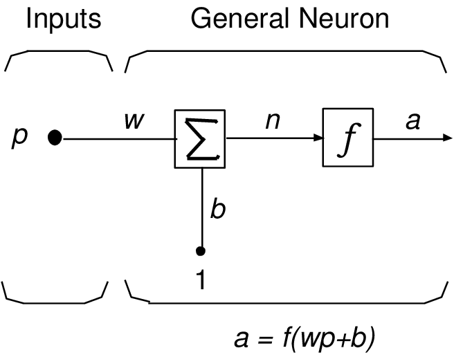

Figure 1: Single input neuron

1 neuron is represented as the summation and a *transfer* function (a type of non-linear activation function). $w$ is weight, $b$ is bias(another weight which is usually to give non-zero value). So, the single neuron out is calculated as

$$a = f(wp +b)$$

And if for example, $w=3, p =2,$ and $b =-1.5$, then

$$a = f(3(2)-1.5) = f(4.5)$$
From vector perspective, we can wrote above like the following:

input vector, $\vec{i} = \begin{bmatrix} p \\ 1 \\ \end{bmatrix}$

parameter vector, $\vec{r} = \begin{bmatrix} w \\ b \\ \end{bmatrix}$

So, to compute:

$$wp + b = [w b] \begin{bmatrix} p \\ 1 \\ \end{bmatrix} \qquad(1)$$

From Equation 1, we can deduce that:

$$wp + b = \vec{r}^T \cdot \vec{i}$$

So, the dot product between the parameter vector and input vector is taken, and a function is applied to it and given as output. The dot product between two vectors is the *projection of one vector on the other*.We can say then, a neuron maps the *similarity*(from projection) between the parameter vector and the input vector to the output through the transfer function. It **“maps”** the amount the parameter vector agrees with the input vector to the output through the transfer function.

Output $a$ from Figure 1 is called a **representation** of the input $p$.

Now, consider the following:

$$f(X) = \sum_{m=1}^{M}g_{m}(\omega_{m}^TX)$$

where we have an input vector $X$ with *p* components, and a target $Y$. Let $\omega_{m}$, $m=1,2,...,M$, be unit *p*-vectors of unknown parameters. Above algorithms approximate a general function of p variables by a sum of nonlinear functions of linear combinations.<sup>2</sup>

The scalar variable $V_{m}=\omega_{m}^TX$ is the projection of $X$ onto the unit vector $\omega_{m}$, and we want $\omega_{m}$ so that the model fits well.

To visualize above statement consider Figure 2 and Figure 3 below.

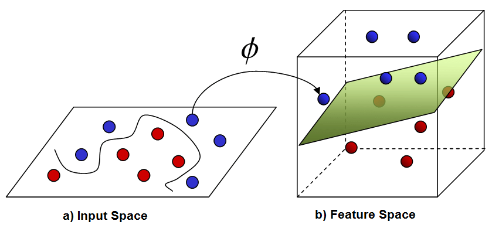

Figure 2: input vector projected to feature space<sup>3</sup>

Another way

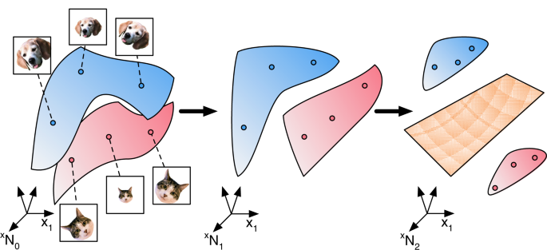

Figure 3: input vector projected to feature space<sup>4</sup>

Thus, we can say that the central idea of NN is to extract linear combinations of the inputs as derived features, and then model the target as a nonlinear function of these features.

So, NN is just a very complex *geometric transformation* in a high-dimensional space, of the input data. Uncrumpling the “input data” is what machine learning is about: finding neat representations for complex, highly folded data *manifolds* in high-dimensional spaces.<sup>5</sup>

For classification problem, a **“decision boudary”** is build in feature space *hyperplane* where features are **“seperable”**.